# Bayesian modeling and prediction for movies

## Setup

### Load packages

```r
library(tidyverse)
library(statsr)
library(GGally)
library(BAS)
```

### Load data

```r
load("movies.Rdata")
```

## Part 1: Data

The intro to the codebook says it best:

> The data set is comprised of 651 randomly sampled movies produced and released before 2016.

> Some of these variables are only there for informational purposes and do not make any sense to include in a statistical analysis. It is up to you to decide which variables are meaningful and which should be omitted. For example information in the the actor1 through actor5 variables was used to determine whether the movie casts an actor or actress who won a best actor or actress Oscar.

> You might also choose to omit certain observations or restructure some of the variables to make them suitable for answering your research questions.

> When you are fitting a model you should also be careful about collinearity, as some of these variables may be dependent on each other.

Because the data is observational in nature, no causal statements can be made from it. However, since it is observational and definitely less than 10% of all movies made in the time period being considered, the conclusions made here can reasonably be extended to the population as a whole.

That said, it is worth noting there is a degree of risk using this data to extend to the general population. There is selection risk in the data. The people who filled in the data are the ones that specifically went to the website because they were compelled to do so. No everyone in the population has access to the Internet nor are interested in submitting this information. Further, only the people wishing to enter this information are doing so. Thus, there is no random assignment in this data.

## Part 2: Data manipulation

Per instruction, we will be mutating a few variables and removing others that we know, prior to analysis, are not useful in predicting `audience_score`. This will leave us with a data frame consisting of 651 observations of 17 variables.

```r
movies <- movies %>% mutate("feature_film" = "no", "drama" = "no", "mpaa_rating_R" = "no", "oscar_season" = "no", "summer_season" = "no")
movies$feature_film[movies$title_type == "Feature Film"] <- "yes"
movies$drama[movies$genre == "Drama"] <- "yes"
movies$mpaa_rating_R[movies$mpaa_rating == "R"] <- "yes"
movies$oscar_season[movies$thtr_rel_month %in% c(10, 11, 12)] <- "yes"
movies$summer_season[movies$thtr_rel_month %in% c(5, 6, 7, 8)] <- "yes"
movies <- movies %>% select(feature_film, drama, runtime, mpaa_rating_R, thtr_rel_year, oscar_season, summer_season, imdb_rating,
                            imdb_num_votes, critics_score, best_pic_nom, best_pic_win, best_actor_win, best_actress_win,
                            best_dir_win, top200_box, audience_score)
summary(movies)
```

```
##  feature_film          drama              runtime      mpaa_rating_R
##  Length:651         Length:651         Min.   : 39.0   Length:651
##  Class :character   Class :character   1st Qu.: 92.0   Class :character
##  Mode  :character   Mode  :character   Median :103.0   Mode  :character
##                                        Mean   :105.8
##                                        3rd Qu.:115.8
##                                        Max.   :267.0
##                                        NA's   :1
##  thtr_rel_year  oscar_season       summer_season       imdb_rating
##  Min.   :1970   Length:651         Length:651         Min.   :1.900
##  1st Qu.:1990   Class :character   Class :character   1st Qu.:5.900
##  Median :2000   Mode  :character   Mode  :character   Median :6.600
##  Mean   :1998                                         Mean   :6.493
##  3rd Qu.:2007                                         3rd Qu.:7.300
##  Max.   :2014                                         Max.   :9.000
##
##  imdb_num_votes   critics_score    best_pic_nom best_pic_win
##  Min.   :   180   Min.   :  1.00   no :629      no :644
##  1st Qu.:  4546   1st Qu.: 33.00   yes: 22      yes:  7
##  Median : 15116   Median : 61.00
##  Mean   : 57533   Mean   : 57.69
##  3rd Qu.: 58300   3rd Qu.: 83.00
##  Max.   :893008   Max.   :100.00
##
##  best_actor_win best_actress_win best_dir_win top200_box audience_score
##  no :558        no :579          no :608      no :636    Min.   :11.00
##  yes: 93        yes: 72          yes: 43      yes: 15    1st Qu.:46.00
##                                                          Median :65.00
##                                                          Mean   :62.36
##                                                          3rd Qu.:80.00
##                                                          Max.   :97.00
##
```

## Part 3: Exploratory data analysis

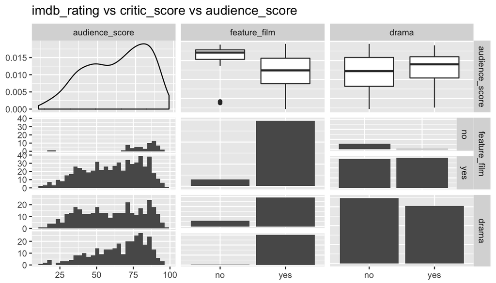

```r
ggpairs(movies, columns = c("audience_score", "feature_film", "drama"), title = "imdb_rating vs critic_score vs audience_score")
```

It’s interesting to note that for almost all films not rated as a feature film, scores are very high. Let’s see how the remaining new variables stack up to `audience_score`.

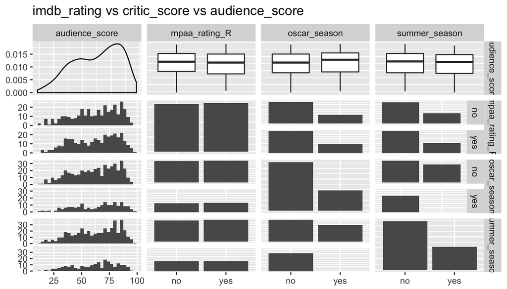

```r
ggpairs(movies, columns = c("audience_score", "mpaa_rating_R", "oscar_season", "summer_season"), title = "imdb_rating vs critic_score vs audience_score")
```

It looks like the distribution of films among the other variables is quite uniform. This is a helpful condition check for Bayesian analysis.

## Part 4: Modeling

Let’s start modeling. To begin with we are going to use 90% of the movie data, with `NA` values removed, as training data for each of four types of estimators: **BMA**, **HPM**, **MPM**, and **BPM**. We’ll then use the model generated under each estimator to fit the remaining 10% of the data and analyze the results to find the best fitting model for our needs.

```r
set.seed(1024)

movies_no_na <- na.omit(movies)

n = nrow(movies_no_na)
n_cv = 50
ape = matrix(NA, ncol = 4, nrow = n_cv)
colnames(ape) <- c("BMA", "BPM", "HPM", "MPM")

for (i in 1:n_cv) {
    train = sample(1:n, size = round(.9 * n), replace = FALSE)
    audience_train = movies_no_na[train,]
    audience_test = movies_no_na[-train,]

    bma_train_movies <- bas.lm(audience_score ~ . -audience_score, data = audience_train,
                               prior = "BIC", modelprior = uniform(), initprobs="eplogp")
    yhat_bma = predict(bma_train_movies, audience_test, estimator = "BMA")$fit
    yhat_hpm = predict(bma_train_movies, audience_test, estimator = "HPM")$fit
    yhat_mpm = predict(bma_train_movies, audience_test, estimator = "MPM")$fit
    yhat_bpm = predict(bma_train_movies, audience_test, estimator = "BPM")$fit
    ape[i, "BMA"] <- cv.summary.bas(yhat_bma, audience_test$audience_score)
    ape[i, "BPM"] <- cv.summary.bas(yhat_bpm, audience_test$audience_score)
    ape[i, "HPM"] <- cv.summary.bas(yhat_hpm, audience_test$audience_score)
    ape[i, "MPM"] <- cv.summary.bas(yhat_mpm, audience_test$audience_score)
}
```

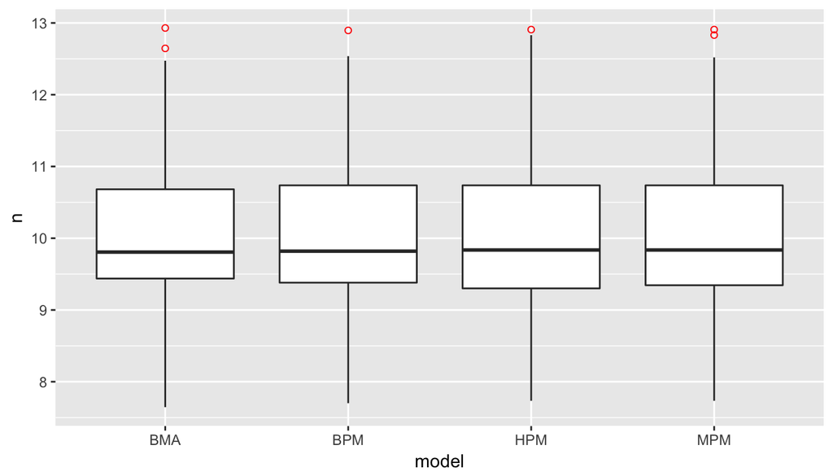

```r
as.data.frame(ape) %>% gather("model", "n", 1:4) %>%
    ggplot(mapping = aes(x = model, y = n)) +
    geom_boxplot(outlier.colour = "red", outlier.shape = 1)
```

We can see the distribution of values is pretty uniform.

```r
apply(ape, 2, mean)
```

```
##      BMA      BPM      HPM      MPM
## 10.01992 10.03973 10.05142 10.05621
```

And we can see from the above that the **BMA** model edged out the other three in predictive performance. For what it’s worth, they’re all very close. How do the residuals stack up?

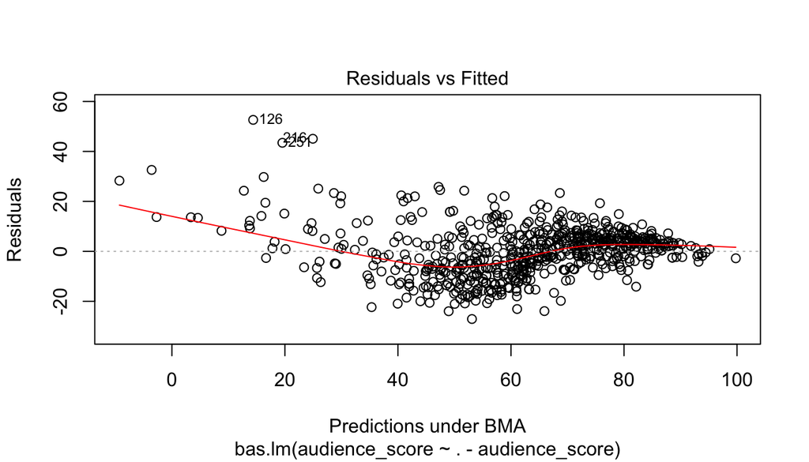

```r
bma_audience = bas.lm(audience_score ~ . -audience_score, data = movies_no_na,
                   prior = "BIC",
                   modelprior = uniform())
plot(bma_audience, which=1)
```

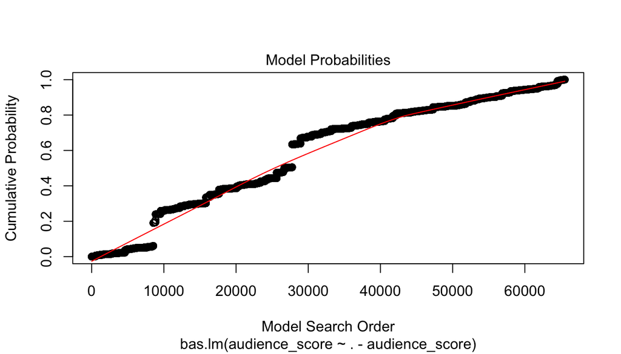

```r
plot(bma_audience, which=2)
```

Based on the residuals, it doesn’t appear as though prediction accuracy is very high for movies with historical values less than 40. Also notable is the identification of some potential outliers. Data points 126, 216 and 251 could be outliers which skew the results on the low end. We’ll explore this later but for now suffice it to say more exploration is warranted.

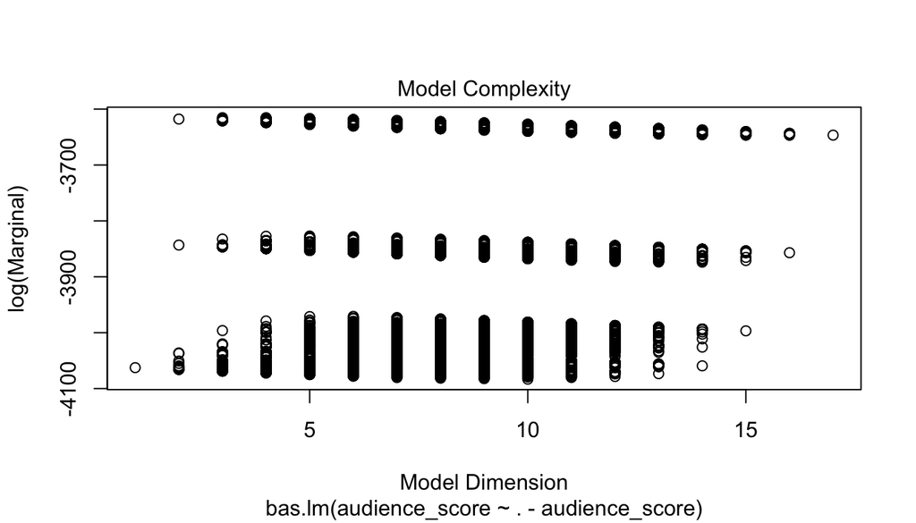

```r
plot(bma_audience, which=3)
```

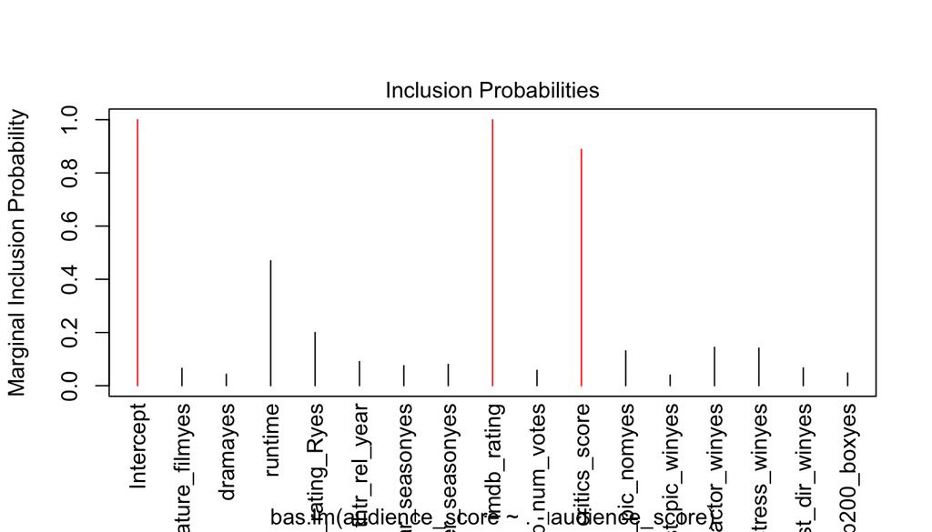

```r
plot(bma_audience, which=4)
```

The above BMA plot shows the variables with the highest predictive probabilities. In this case, `imdb_rating` and `critics_score` both have a very high predictive probability and should thus be included in the final model.

```r
summary(bma_audience)
```

```
##                     P(B != 0 | Y)    model 1       model 2       model 3
## Intercept              1.00000000     1.0000     1.0000000     1.0000000
## feature_filmyes        0.06536947     0.0000     0.0000000     0.0000000
## dramayes               0.04319833     0.0000     0.0000000     0.0000000
## runtime                0.46971477     1.0000     0.0000000     0.0000000
## mpaa_rating_Ryes       0.19984016     0.0000     0.0000000     0.0000000
## thtr_rel_year          0.09068970     0.0000     0.0000000     0.0000000
## oscar_seasonyes        0.07505684     0.0000     0.0000000     0.0000000
## summer_seasonyes       0.08042023     0.0000     0.0000000     0.0000000
## imdb_rating            1.00000000     1.0000     1.0000000     1.0000000
## imdb_num_votes         0.05773502     0.0000     0.0000000     0.0000000
## critics_score          0.88855056     1.0000     1.0000000     1.0000000
## best_pic_nomyes        0.13119140     0.0000     0.0000000     0.0000000
## best_pic_winyes        0.03984766     0.0000     0.0000000     0.0000000
## best_actor_winyes      0.14434896     0.0000     0.0000000     1.0000000
## best_actress_winyes    0.14128087     0.0000     0.0000000     0.0000000
## best_dir_winyes        0.06693898     0.0000     0.0000000     0.0000000
## top200_boxyes          0.04762234     0.0000     0.0000000     0.0000000
## BF                             NA     1.0000     0.9968489     0.2543185
## PostProbs                      NA     0.1297     0.1293000     0.0330000
## R2                             NA     0.7549     0.7525000     0.7539000
## dim                            NA     4.0000     3.0000000     4.0000000
## logmarg                        NA -3615.2791 -3615.2822108 -3616.6482224
##                           model 4       model 5
## Intercept               1.0000000     1.0000000
## feature_filmyes         0.0000000     0.0000000
## dramayes                0.0000000     0.0000000
## runtime                 0.0000000     1.0000000
## mpaa_rating_Ryes        1.0000000     1.0000000
## thtr_rel_year           0.0000000     0.0000000
## oscar_seasonyes         0.0000000     0.0000000
## summer_seasonyes        0.0000000     0.0000000
## imdb_rating             1.0000000     1.0000000
## imdb_num_votes          0.0000000     0.0000000
## critics_score           1.0000000     1.0000000
## best_pic_nomyes         0.0000000     0.0000000
## best_pic_winyes         0.0000000     0.0000000
## best_actor_winyes       0.0000000     0.0000000
## best_actress_winyes     0.0000000     0.0000000
## best_dir_winyes         0.0000000     0.0000000
## top200_boxyes           0.0000000     0.0000000
## BF                      0.2521327     0.2391994
## PostProbs               0.0327000     0.0310000
## R2                      0.7539000     0.7563000
## dim                     4.0000000     5.0000000
## logmarg             -3616.6568544 -3616.7095127
```

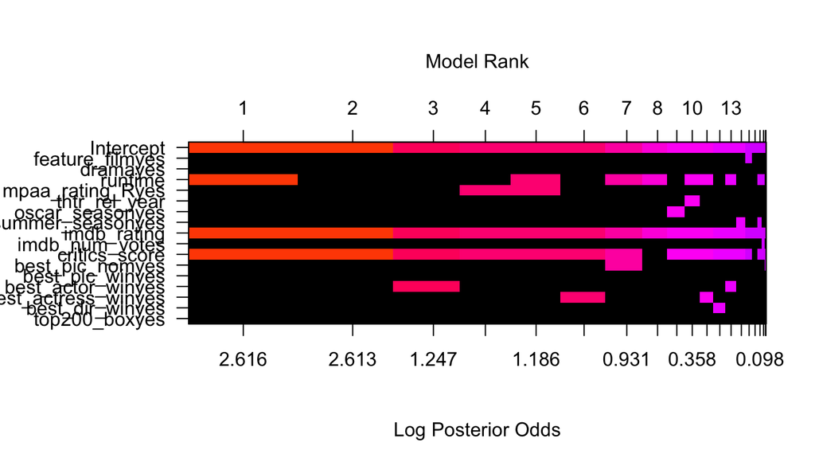

```r
image(bma_audience, rotate = F)
```

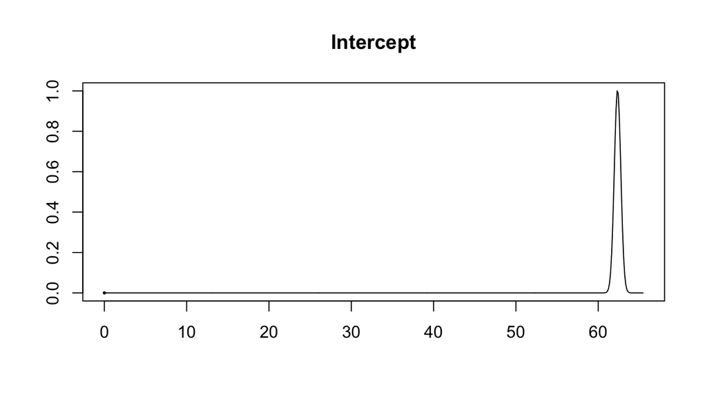

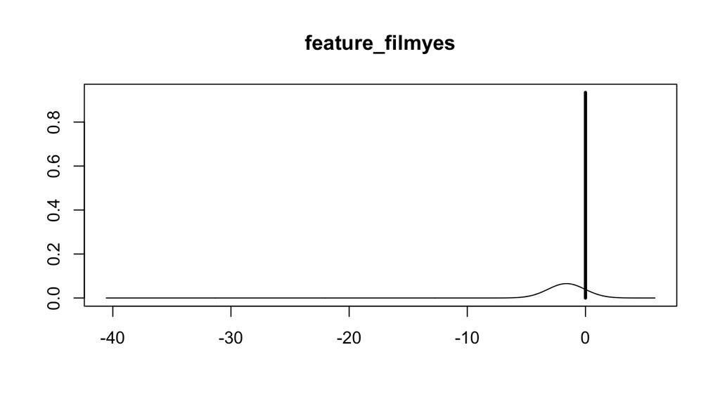

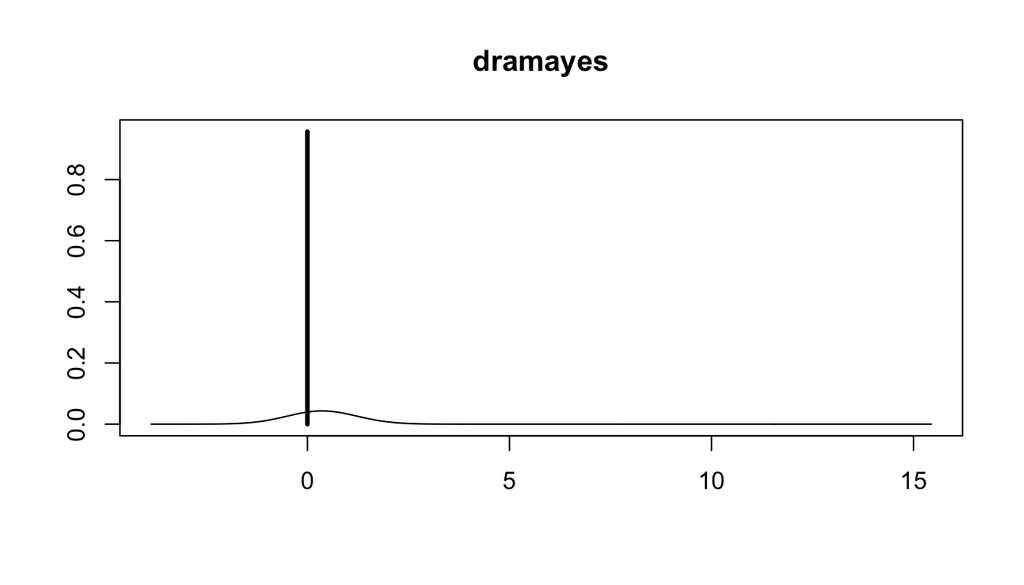

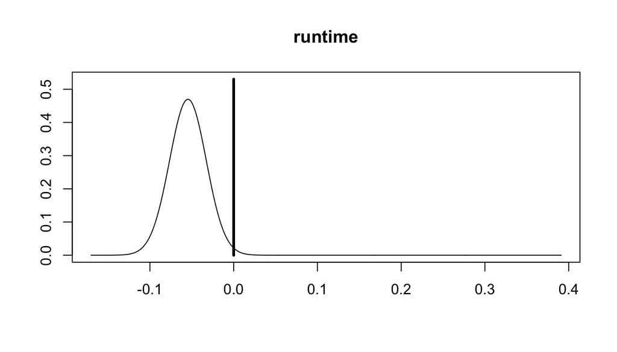

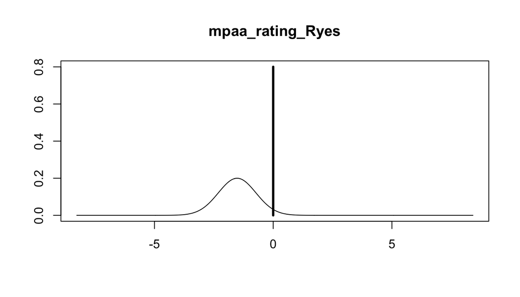

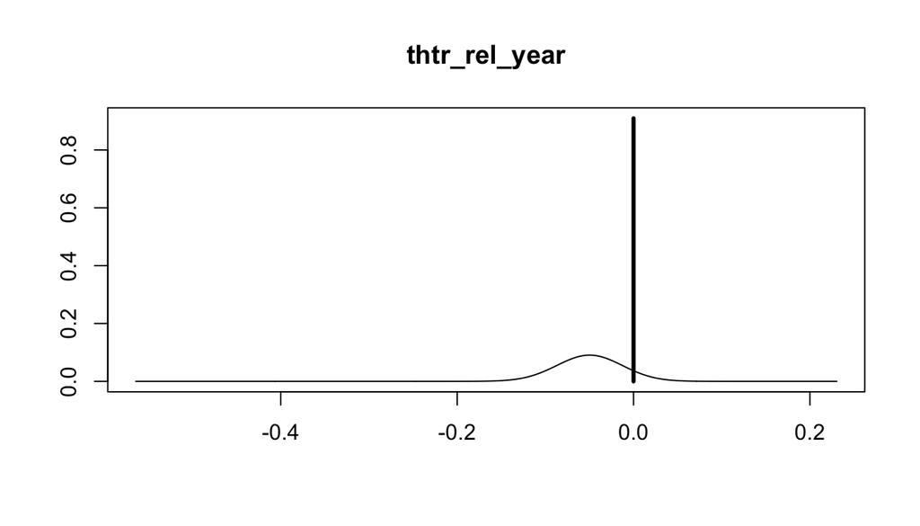

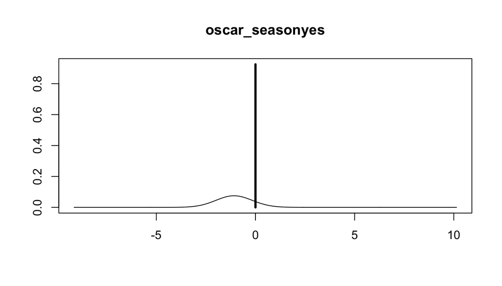

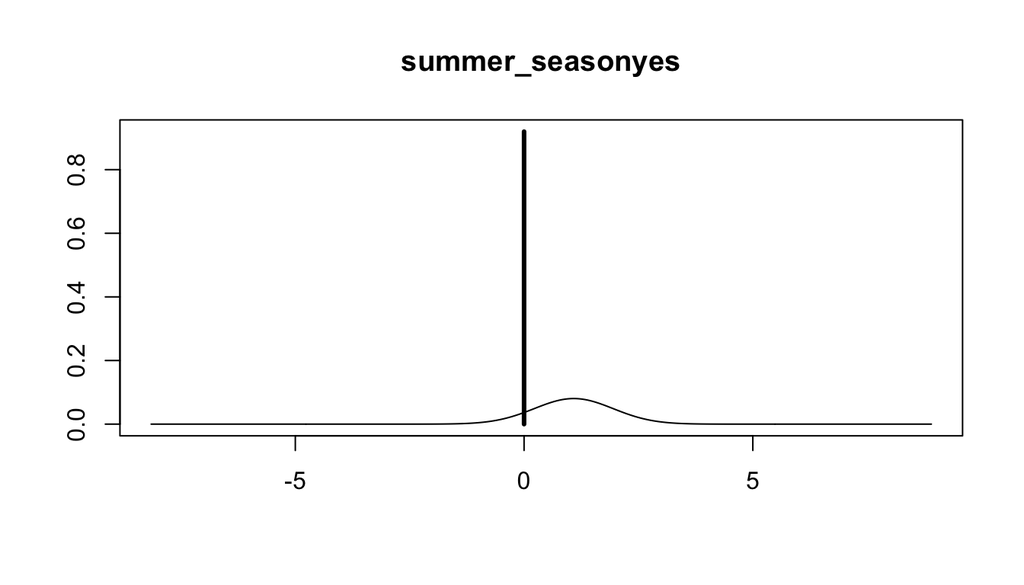

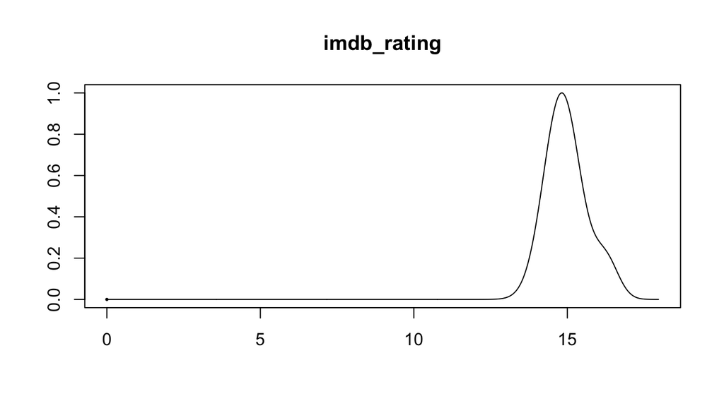

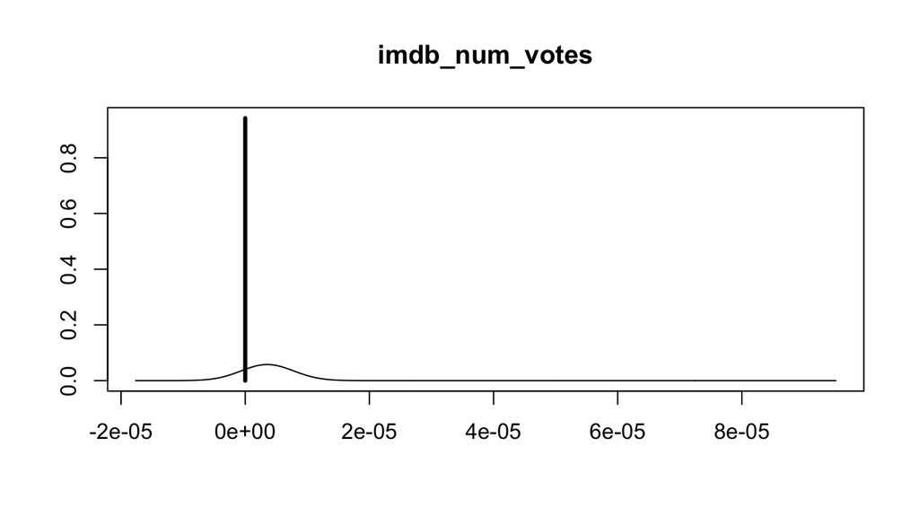

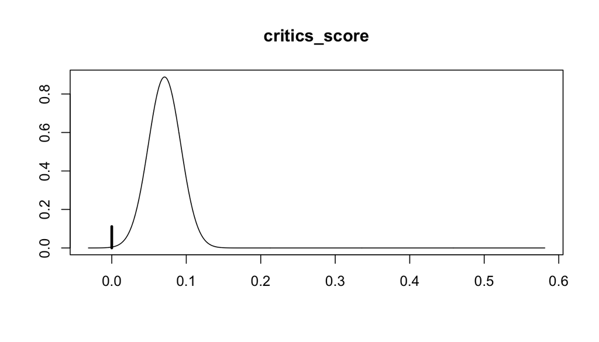

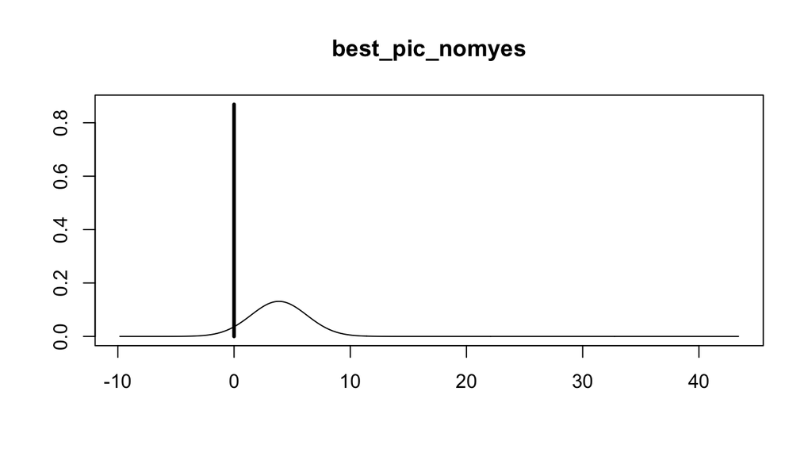

[5 more figures not shown]

```r
coef_bma <- coef(bma_audience)
plot(coef_bma, ask = F)
```

The above credible intervals for the coefficients is based on the mixture model. The box plots below is simply the visualization of these intervals.

```r
confint(coef_bma)
```

```
##                            2.5  %      97.5  %          beta
## Intercept            6.159603e+01 6.314048e+01  6.234769e+01
## feature_filmyes     -1.016391e+00 4.773024e-03 -1.046908e-01
## dramayes             0.000000e+00 0.000000e+00  1.604413e-02
## runtime             -8.347361e-02 0.000000e+00 -2.567772e-02
## mpaa_rating_Ryes    -2.078846e+00 0.000000e+00 -3.036174e-01
## thtr_rel_year       -5.657558e-02 0.000000e+00 -4.532635e-03
## oscar_seasonyes     -1.027970e+00 0.000000e+00 -8.034940e-02
## summer_seasonyes    -2.069984e-03 1.076597e+00  8.704545e-02
## imdb_rating          1.365914e+01 1.654307e+01  1.498203e+01
## imdb_num_votes      -1.956306e-07 1.873196e-06  2.080713e-07
## critics_score        0.000000e+00 1.051910e-01  6.296648e-02
## best_pic_nomyes     -8.487436e-03 4.988447e+00  5.068035e-01
## best_pic_winyes      0.000000e+00 0.000000e+00 -8.502836e-03
## best_actor_winyes   -2.655518e+00 0.000000e+00 -2.876695e-01
## best_actress_winyes -2.718805e+00 0.000000e+00 -3.088382e-01
## best_dir_winyes     -1.282116e+00 1.345931e-02 -1.195011e-01
## top200_boxyes        0.000000e+00 0.000000e+00  8.648185e-02
## attr(,"Probability")
## [1] 0.95
## attr(,"class")
## [1] "confint.bas"
```

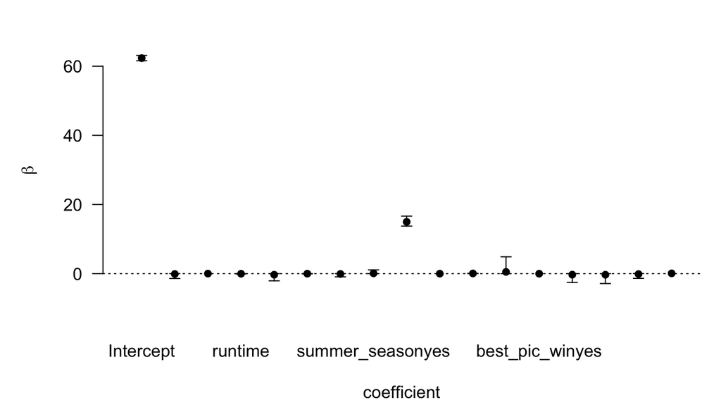

```r
plot(confint(coef_bma))
```

Now let’s take a look at some fitted values versus their predicted values. If all goes as planned then they will be in perfect alignment.

```r
muhat.BMA <- fitted(bma_audience, estimator = "BMA")
BMA <- predict(bma_audience, estimator = "BMA")
```

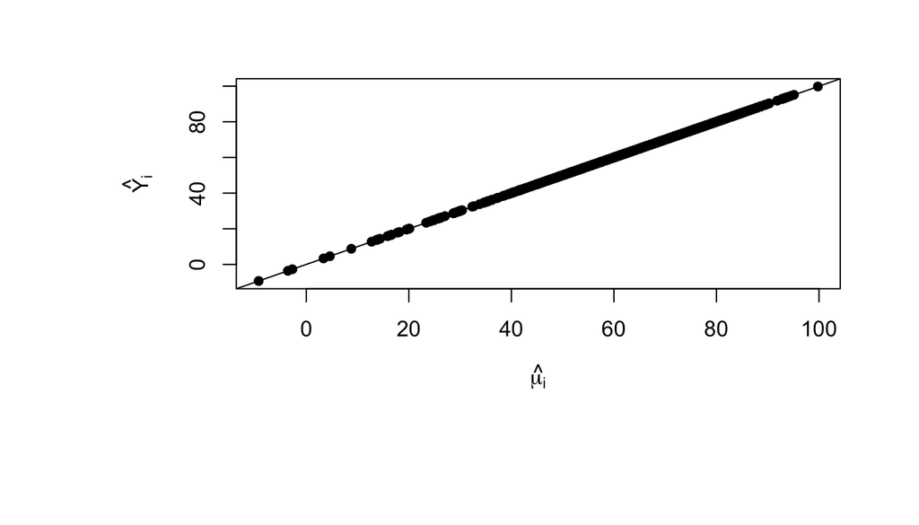

```r
par(mar = c(9,9,3,3))
plot(muhat.BMA, BMA$fit,
     pch=16,
     xlab = expression(hat(mu[i])), ylab = expression(hat(Y[i])))
abline(0,1)
```

Now let’s take a look at those outliers.

```r
set.seed(1024)
n = nrow(movies_no_na)
audience_outliers = cbind(movies_no_na, diag(1, nrow=n))
outliers_audience = bas.lm(audience_score ~ . -audience_score, data=audience_outliers,
                        prior="ZS-null", a=n,
                        modelprior=tr.beta.binomial(a=1, b=1, trunc=n/2),
                        method="MCMC",
                        initprobs="marg-eplogp",
                        MCMC.iterations=500000, n.models=2^15
                        )
```

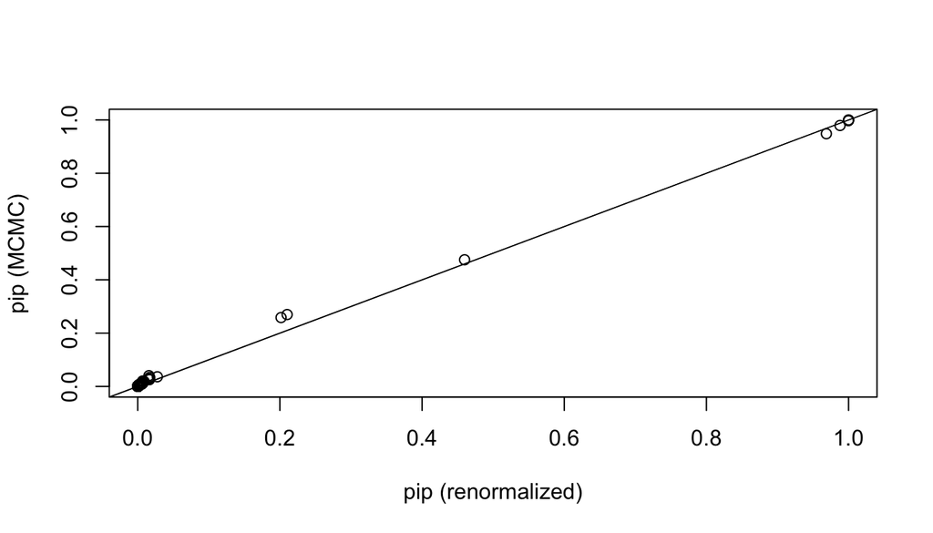

```r
diagnostics(outliers_audience, type="pip")
```

```r
outliers_audience$namesx[outliers_audience$probne0 > .5]
```

```
## [1] "Intercept"   "imdb_rating" "`126`"       "`216`"       "`251`"
```

## Part 5: Prediction

Here we’ll explore a few model options and the merits of each.

**highest probability model**

```r
HPM <- predict(bma_audience, estimator = "HPM")
HPM$bestmodel
```

```
## [1]  0  3  8 10
```

The above list shows the indices of the variables in the best model. 0 is the intercept.

```r
(bma_audience$namesx[HPM$bestmodel + 1])[-1]
```

```
## [1] "runtime"       "imdb_rating"   "critics_score"
```

Instead of the indices, list the variable names.

**median probability model**

```r
MPM <- predict(bma_audience, estimator = "MPM")
(bma_audience$namesx[attr(MPM$fit, 'model') + 1])[-1]
```

```
## [1] "imdb_rating"   "critics_score"
```

As with the highest probability model, let’s look at the list of variable names in the best model.

**best predictive model**

Here we have the model that is the closest to BMA prediction under squared error loss.

```r
BPM <- predict(bma_audience, estimator = "BPM")
(bma_audience$namesx[attr(BPM$fit, 'model') + 1])[-1]
```

```
## [1] "runtime"       "imdb_rating"   "critics_score"
```

Finally, let’s compare all of these models.

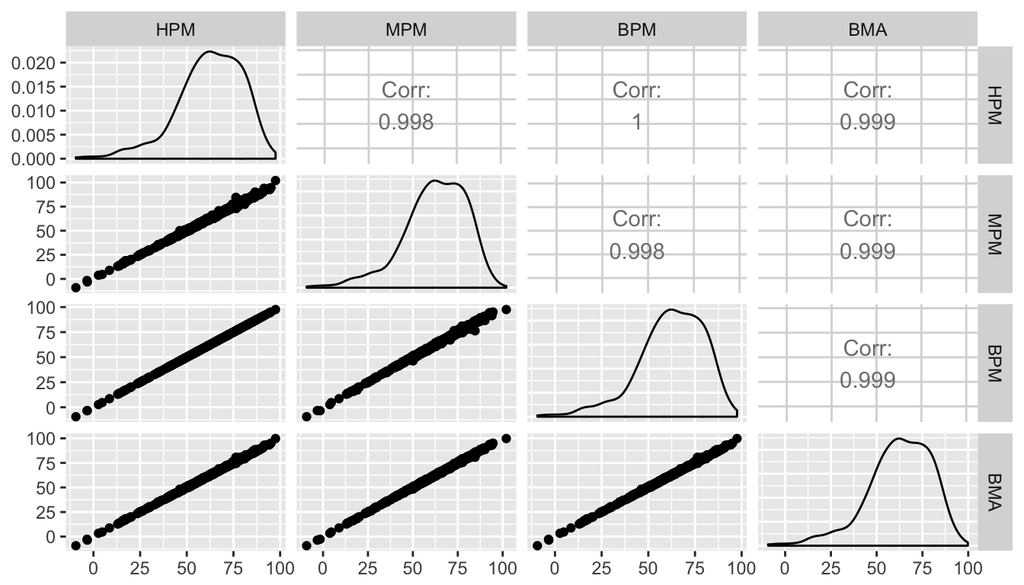

```r
ggpairs(data.frame(HPM = as.vector(HPM$fit),
                   MPM = as.vector(MPM$fit),
                   BPM = as.vector(BPM$fit),
                   BMA = as.vector(BMA$fit)))
```

```r
imdb_rating <- 7.9
critics_score <- 85
feature_film <- "yes"
drama <- "no"
runtime <- 133
mpaa_rating_R <- "no"
thtr_rel_year <- 2016
oscar_season <- "yes"
summer_season <- "no"
imdb_num_votes <- 314436
best_pic_nom <- "no"
best_pic_win <- "no"
best_actor_win <- "no"
best_actress_win <- "no"
best_dir_win <- "no"
top200_box <- "yes"
new_data <- data.frame(imdb_rating, critics_score, feature_film, drama)

new_prediction <- predict(bma_audience, newdata = new_data, estimator = "MPM")
new_prediction[1]
```

```
## $fit
## [1] 85.00594
## attr(,"model")
## [1]  0  8 10
## attr(,"best")
## [1] 1
```

Our model gave this movie a score of 85.01% based on `imdb_rating` and `critics_score`. The actual score on Rotten Tomatoes at the time of this writing is 88%. Not a bad estimate.

## Part 6: Conclusion

The `movies` data set provides a number of categorical and numeric variables for movies in a wide time range. Given the proper elements we can use that information to construct a predictive model for movies that do not exist in our data set. These predictions can help us project many important characteristics of a movie such as its financial success.